# Time Serie Analysis

Anaïs Ladoy

5/12/2018

```r
# LIBRARIES

library(tidyverse) #tibbles
library(tsibble) #manage temporal data frame in tidy form

library(sf) #simple features

library(forecast) #univariate time series forecasts
library(imputeTS) #univariate time series imputation
```

Study case : Chicago Com Ed station.

- almost complete dataset (>90% complete)
- the site is designed to study population exposure, with a neighborhood scale
- there are two PM2.5 sensors at this location (with non-calibrated though) but it can still be interesting to compare the trend

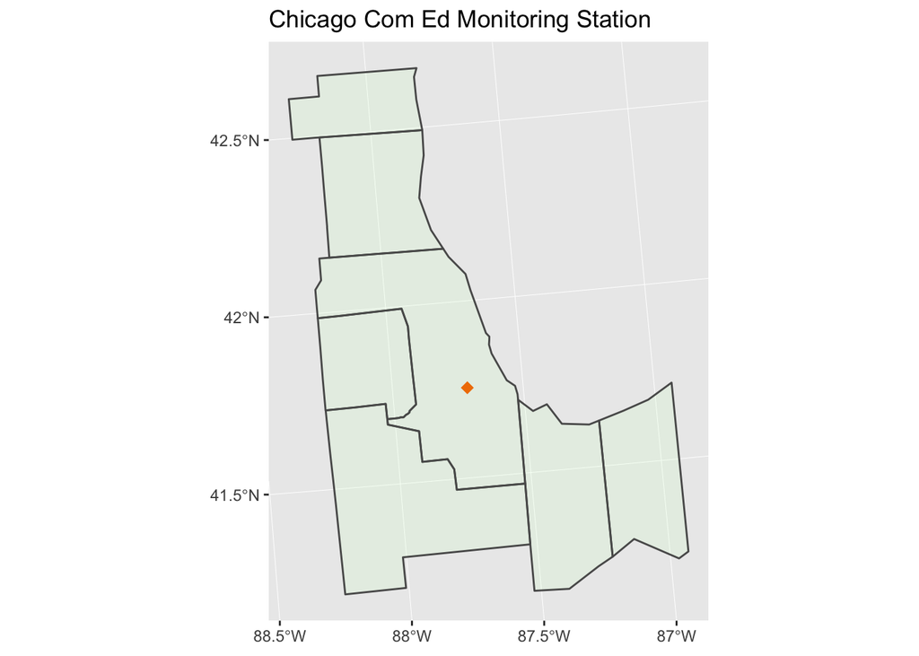

```r
#Load data
counties <- read_sf('Data/Spatial/counties.shp') #study area
MS <- read_sf('Data/Spatial/MS_PM25.shp') %>% filter(AQSID=='170310076') #metadata for the MS
data <- read_csv('Data/CSV/data_PM25.csv') %>% filter(AQSID=='170310076') #data for the MS

#Visualize the location of the MS in the study area
ggplot() + geom_sf(data=counties,fill="#d3ffce",alpha=0.2) + geom_sf(data=MS,colour="#f07d00",pch=18,cex=3) + ggtitle('Chicago Com Ed Monitoring Station')
```

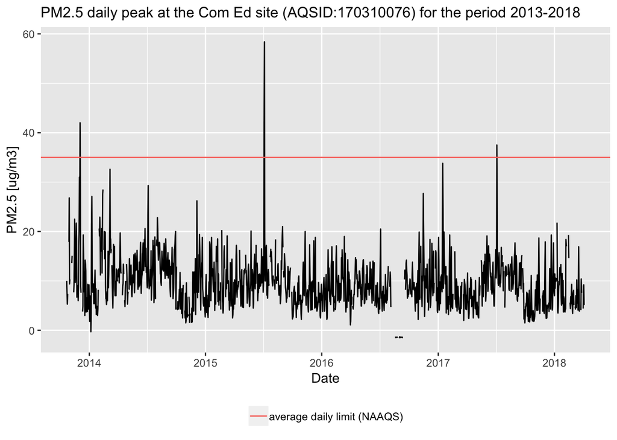

```r
#Data conversion
data <- as_tsibble(data,key=id(AQSID),index=date) #conversion to time series
data <- rename(data, value=PM25) #change the name of the column to a more generic one

#Graphic parameters
title <- 'PM2.5 daily peak at the Com Ed site (AQSID:170310076) for the period 2013-2018'
xlab <- 'Date'
ylab <- 'PM2.5 [ug/m3]'

#Plot the time serie with the average daily limit according US.EPA
data %>% ggplot(aes(x=date, y=value)) + geom_line() + geom_hline(aes(yintercept=35,colour='average daily limit (NAAQS)')) + labs(title=title, x=xlab, y=ylab) + theme(legend.title=element_blank(),legend.position='bottom',plot.title = element_text(size = 12))
```

The daily peak values of the PM2.5 concentration don’t show a particular trend but it seems that seasonality is present in the time series, with higher values of PM2.5 during summer. Time series patterns will be further studied in the following section.

It is important to note that the red line, showing the PM2.5 limit according to the National Air Quality Standards (NAAQS) concern daily average and not daily peak. Thus, we cannot say that there are exceedances to the NAAQS standards. However, it allows to detect particulary high values of the PM2.5 concentration at three different days, that could be harmful for the exposed population.

During 2016 summer, we can detect points of PM2.5 concentration that seem negative. Indeed, 24 days recorded negative values which is completely impossible in reality, this may correspond period with sensor malfunction and the data were falsely keepen in the dataset. These values are replaced by NA (missing values). I will add a step in the cleaning process to detect if this problem appear in other time series.

```r
#Print rows with negative values for the PM2.5 concentration (inconsistent values)
data %>% filter(!is.na(value) & value<0)
```

```
## # A tsibble: 24 x 3 [1DAY]
## # Keys:      AQSID [1]
##    date           AQSID  value
##    <date>         <int>  <dbl>
##  1 2014-01-06 170310076 -0.300
##  2 2016-08-18 170310076 -1.40
##  3 2016-08-19 170310076 -1.40
##  4 2016-08-20 170310076 -1.40
##  5 2016-08-21 170310076 -1.50
##  6 2016-08-22 170310076 -1.40
##  7 2016-08-23 170310076 -1.40
##  8 2016-08-24 170310076 -1.40
##  9 2016-08-25 170310076 -1.40
## 10 2016-08-26 170310076 -1.40
## # ... with 14 more rows
```

```r
#Replace the negative values by NA
data <- data %>% mutate(value=replace(value,value<0,NA))
```

Discontinuities in the time serie reveal periods with missing values. Various reasons can generate missing values in the dataset and numerous methods can be used to handle missing values. The more common ones are to discard missing values but we may lose useful information or to replace them by a specific values (e.g. overall mean) but we may ignore intrinsic variability and include bias.

In my case, I cannot discard missing values as further analysis steps (e.g. forecast) rely on complete time series. Furthermore, the standard methods for the imputation process rely on inter-attribute correlations to estimate values for the missing data so working with an univariate time serie is even more complicated.

Thus, it is important to understand the mechanism that generate missing values and the different patterns of the univariate time serie to choose an optimal method for the imputation.

## Time serie EDA

### Missing values

Let $Y=(Y_{obs},Y_{min})$ denotes the complete set of data which would be available without missing values where $Y_{obs}$ are the observed data and $Y_{mis}$ the missing observations. $R_i$ denotes an indicator which is equal to 1 if $Y_i$ is missing and 0 if not. According to the notation proposed by Little and Rubin (2014), the missing data mechanism can be classified in three ways :

- completely random (MCAR) if $R_i$ is independant of both $Y_{obs}$ and $Y_{mis}$
- random (MAR) if $R_i$ is independant of $Y_{mis}$
- informative if $R_i$ is dependant of $Y_{mis}$

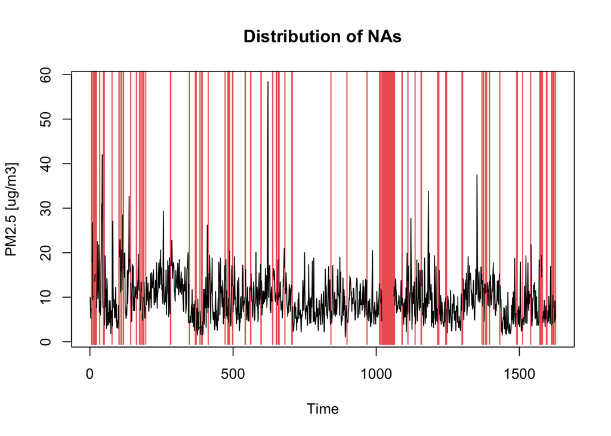

```r
#Distribution of missing values in the time serie
plotNA.distribution(data$value,pch=NA,ylab=ylab)
```

```r
#Statistics about missing values
statsNA(data$value)
```

```
## [1] "Length of time series:"
## [1] 1627
## [1] "-------------------------"
## [1] "Number of Missing Values:"
## [1] 168
## [1] "-------------------------"
## [1] "Percentage of Missing Values:"
## [1] "10.3%"
## [1] "-------------------------"
## [1] "Stats for Bins"
## [1] "  Bin 1 (407 values from 1 to 407) :      44 NAs (10.8%)"
## [1] "  Bin 2 (407 values from 408 to 814) :      24 NAs (5.9%)"
## [1] "  Bin 3 (407 values from 815 to 1221) :      61 NAs (15%)"
## [1] "  Bin 4 (406 values from 1222 to 1627) :      39 NAs (9.61%)"
## [1] "-------------------------"
```

[output cut: 16 more lines]

```r
#Which day of the week the missing values appear?
data %>% filter(is.na(value)) %>% mutate(weekday=weekdays(date)) %>% mutate(weekday=factor(weekday,levels = c('Monday','Tuesday','Wednesday','Thursday','Friday','Saturday','Sunday') )) %>%  select(weekday,.drop=TRUE) %>% group_by(weekday)%>% summarise(nb_NA=n())
```

```
## # A tibble: 7 x 2
##   weekday   nb_NA
##   <fct>     <int>
## 1 Monday       31
## 2 Tuesday      18
## 3 Wednesday    21
## 4 Thursday     19
## 5 Friday       22
## 6 Saturday     28
## 7 Sunday       29
```

As we may expect with daily sensors data, there are a lot of missing values in the dataset (168 days without PM2.5 daily peak value) representing *10.3%* of the entire dataset. Moreover, these data seem randomly distributed along the time series which can suggest instrument malfunction.

We can also detect a huge gap in the time serie with 42 consecutive days with no data, around september 2016. Nevertheless, the gap size is usually short (1 or 2 days).

In our case, the missing values could be due to sensors malfunction (MCAR) or correspond to days where sensors status are checked (e.g. first suday of the month) and the latter would be a MAR mechanism. We cannot detect a pattern in the weekday where missing data appear so we can consider the missing value process to be MCAR.

### Imputation of missing values

Chelani (2010) for the daily maximum ground-level ozone concentration, has 7% of missing values in the time series and replaces with previous day’s observed values. -> First, the ozone peak can change a lot between two days at the same location (could be valid if we would use daily average) and in my case, periods concern consecutive days most of the time so I would borrow the value of 3-4 days before, which doesn’t seem appropriate.

Expectation-Maximisation (EM) algorithm (possible in Amelia package)

Model-based likelihood method : Model the missing data mechanism and then proceed to make a proper likelihood-based analysis, either via the method of maximum-likelihood or using Bayesian methods.

For now, just use mean to replace missing values in order to have a complete time series and continue the analysis.

```r
#Replace missing values by mean (temporary solution !!)
data <- data %>% mutate(value=replace(value,is.na(value),mean(data$value,na.rm=TRUE)))
```

Use low pass filter to remove the noise and see the trend in the time series. Or use frequency (tsibble)

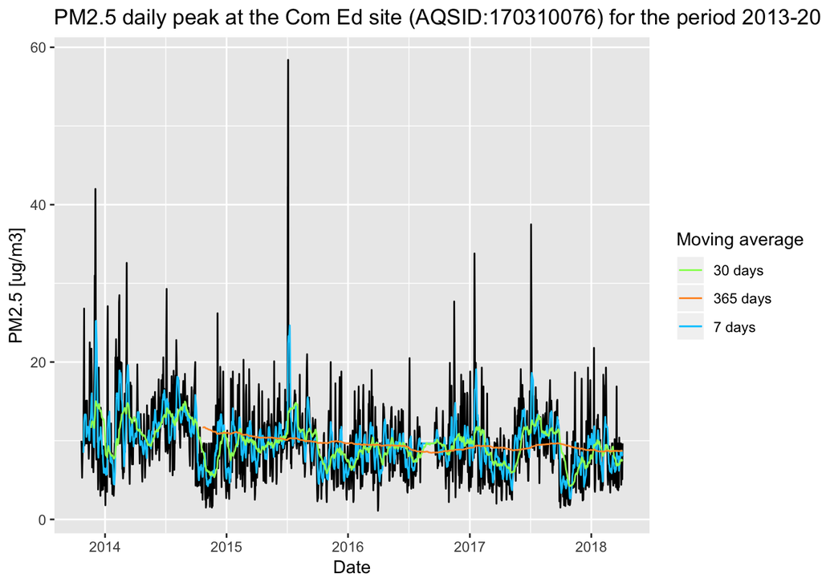

```r
data %>% ggplot() + geom_line(aes(x=date,y=value)) + geom_line(aes(x=date,y=slide(value,~ mean(.,na.rm=TRUE),size = 7),colour='7 days')) + geom_line(aes(x=date,y=slide(value,~ mean(.,na.rm=TRUE),size = 30),colour='30 days')) + geom_line(aes(x=date,y=slide(value,~ mean(.,na.rm=TRUE),size = 365),colour='365 days')) + labs(colour ="Moving average") + scale_colour_manual(values = c("7 days" = "#00ccff", "30 days" = "#99ff66", "365 days" = "#ff9933")) + labs(title=title, x=xlab, y=ylab)
```

### Imputation of missing values

Getting trend and seasonnal effects right can improve forecasting, and even imputation results a lot

Seasonality (seems higher during summer) but no trend acf for autocorrelation

## Several possibilities for the imputation of univariate missing data

## Applications to the Array of Things

- impution but multivariate this time (several parameters measured at the same node)
- use spatial dependence ?
- compute an AQI ?
- short term forecast of the values ?

## Sources

- Moritz, “Comparison of Different Methods for Univariate Time Series Imputation in R.”
- Shaddick and Zidek, Spatio-Temporal Methods in Environmental Epidemiology.